# Chapter3 Factorial designs

## Example 1.2 : Determining the number of replicates

one of two possible methods can be followed. 1. detecting differences among the cell means. 2. detecting a practical size difference in the marginal means for the factors in the experiment ???

From pilot tests, the standard deviation of experimental error can be estimated as s = 0.32, and if D(delta) = 1.0 is considered to be a practical size difference in CELL MEANS, powers can be calculated like below. In case 4-by-4 factorial, there are 16cells ; nlevel-= 16

```r
power
```

```
     alpha nlev nreps Delta sigma   power
[1,]  0.05   16     2     1  0.32 0.24173
[2,]  0.05   16     3     1  0.32 0.48174
[3,]  0.05   16     4     1  0.32 0.69246
[4,]  0.05   16     5     1  0.32 0.83829
[5,]  0.05   16     6     1  0.32 0.92326
[6,]  0.05   16     7     1  0.32 0.96664
[7,]  0.05   16     8     1  0.32 0.98655
```

if D = 1.0 is considerd to be a practical size difference in MARGINAL MEANS for one of the factors, the result will be different, User Fpower2 function

```r
power <- Fpower2(0.05, nlev = , nreps = 2:8, Delta = 1, sigma = 0.32)
options(digits = 5)
power
```

[output not shown]

どう解釈すべきか？

## Example 2.2 : Analysis of lacking data

If there is an unequal number of replicates per cell, marginal mean would be not unbiased. ‘noncentrality for the F-test will be a quadratic form’ –> ???

```r
COdatam <- daewr::COdata
COdatam[18,3] <- NA
library(car)
mod2 <- lm(CO ~ Eth*Ratio, data = COdatam,
           contrasts = list(Eth = contr.sum, Ratio = contr.sum))
Anova(mod2, type = 'III')
```

```
Anova Table (Type III tests)

Response: CO
            Sum Sq Df   F value    Pr(>F)
(Intercept)  86198  1 15496.351 1.939e-14 ***
Eth            319  2    28.715 0.0002235 ***
Ratio          511  2    45.973 4.105e-05 ***
Eth:Ratio      555  4    24.945 0.0001427 ***
Residuals       44  8
---
Signif. codes:  0 ‘***’ 0.001 ‘**’ 0.01 ‘*’ 0.05 ‘.’ 0.1 ‘ ’ 1
```

## Example . One replication per cell.

with N=1, ANOVA ssE cannot be calculated and no way t make F-test. if the levels of both foactors are quantitative, the sum of squares for the interaction term can be partitioned into orthogonal polynomial single degrees of freedom. 両ファクターが数値であればinteraction の項が直交多項式？にわけられる ？？？

```r
anova(modnr)
```

```
ANOVA F-tests on an essentially perfect fit are unreliable
```

```
Analysis of Variance Table

Response: Cellmeans
          Df Sum Sq Mean Sq F value Pr(>F)
Eth        2    162   81.00
Ratio      2    326  163.00
Eth:Ratio  4    339   84.75
Residuals  0      0
```

To get sums of square for the linear * linear portion of interactopm, the factors are converted to ordered factors.

```r
Ethc <- as.ordered(cells$Eth)
class(Ethc)
Ratioc <- as.ordered(cells$Ratio)
```

When ordered factors are used, lm uses orthogonal polynomial contrasts… ??

## Example 3. Multiple factors

factor : 3x3x2x2=36 pattern of website responce : signup or not

```r
library(daewr)
data(web)
web
```

the responce is binorminal, and aggregated form, meaning same as no replication case. ssE cannot be calculated for F-test.glm function automatically set sigma^2 = 1.0 and type III sums of squares will be asymptotically distributed as chi-squareas…?

```r
modb <- glm(cbind(signup, visitors-signup) ~ A*B*C*D, data = web, family = binomial)
summray(modb)
anova(modb, test = 'Chisq')
```

[output not shown]

```r
prop <- web$signup / web$visitors
webp <- data.frame(web, prop)
par(mfrow = c(1,3))
webp1 <- subset(webp, A == 1)
interaction.plot(webp1$C, webp1$D, webp1$prop, ylim = c(0.015,0.0275))
webp2 <- subset(webp, A == 2)
interaction.plot(webp2$C, webp2$D, webp2$prop, ylim = c(0.015,0.0275))
```

[figure not shown]

```r
webp3 <- subset(webp, A == 3)
interaction.plot(webp3$C, webp3$D, webp3$prop, ylim = c(0.015,0.0275))
```

```r
NA
NA
```

結局ひとつづつ見ていくしかない

## Example 4. Two level factorial

ここでは全組み合わせをやる前提。 2 levels ^3 factor * 2 replication = 16 runs

contr.FrF2 perform scaling.

```r
summary(modv)
```

```
Call:
lm(formula = y ~ A * B * C, data = volt, contrasts = list(A = DoE.base::contr.FrF2,
    B = DoE.base::contr.FrF2, C = DoE.base::contr.FrF2))

Residuals:
   Min     1Q Median     3Q    Max
-21.50 -11.75   0.00  11.75  21.50

Coefficients:
            Estimate Std. Error t value Pr(>|t|)
(Intercept) 668.5625     4.5178 147.985 4.86e-15 ***
A1          -16.8125     4.5178  -3.721  0.00586 **
B1            0.9375     4.5178   0.208  0.84079
C1            5.4375     4.5178   1.204  0.26315
A1:B1        -6.6875     4.5178  -1.480  0.17707
A1:C1        12.5625     4.5178   2.781  0.02390 *
B1:C1         1.8125     4.5178   0.401  0.69878
A1:B1:C1     -5.8125     4.5178  -1.287  0.23422
---
Signif. codes:  0 ‘***’ 0.001 ‘**’ 0.01 ‘*’ 0.05 ‘.’ 0.1 ‘ ’ 1

Residual standard error: 18.07 on 8 degrees of freedom
Multiple R-squared:  0.772, Adjusted R-squared:  0.5724
F-statistic: 3.869 on 7 and 8 DF,  p-value: 0.0385
```

A and AxC interaction are significant. the effect of A is twice the regression coefficient, meaning, on the avaragem when the A is increased from 22 to 32deg, the coltage measurement will decrease by 16.8125*2.

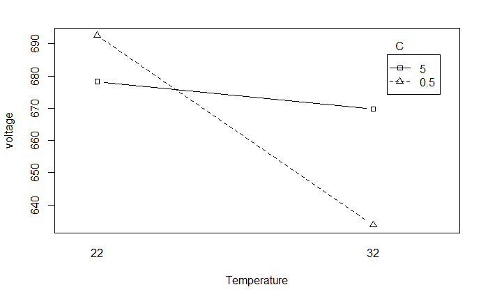

```r
with(volt, (interaction.plot(A, C, y, type = "b",
                             pch = c(24,22), leg.bty = "o",
                             xlab = "Temperature", ylab = "voltage"))
     )
```

## Example 5. one replicates per cell

```r
library(daewr)
chem
```

| A | B | C | D | y |
| --- | --- | --- | --- | --- |
| -1 | -1 | -1 | -1 | 45 |
| 1 | -1 | -1 | -1 | 41 |
| -1 | 1 | -1 | -1 | 90 |
| 1 | 1 | -1 | -1 | 67 |
| -1 | -1 | 1 | -1 | 50 |
| 1 | -1 | 1 | -1 | 39 |
| -1 | 1 | 1 | -1 | 95 |
| 1 | 1 | 1 | -1 | 66 |
| -1 | -1 | -1 | 1 | 47 |
| 1 | -1 | -1 | 1 | 43 |

[output cut: 6 more lines]

```r
modf <- lm(y~ A*B*C*D, data = chem)
summary(modf)
```

```
Call:
lm(formula = y ~ A * B * C * D, data = chem)

Residuals:
ALL 16 residuals are 0: no residual degrees of freedom!

Coefficients:
            Estimate Std. Error t value Pr(>|t|)
(Intercept)  62.3125         NA      NA       NA
A            -6.3125         NA      NA       NA
B            17.8125         NA      NA       NA
C             0.1875         NA      NA       NA
D             0.6875         NA      NA       NA
A:B          -5.3125         NA      NA       NA
A:C           0.8125         NA      NA       NA
B:C          -0.3125         NA      NA       NA
A:D           2.0625         NA      NA       NA
B:D          -0.0625         NA      NA       NA
C:D          -0.6875         NA      NA       NA
A:B:C        -0.1875         NA      NA       NA
A:B:D        -0.6875         NA      NA       NA
A:C:D         2.4375         NA      NA       NA
B:C:D        -0.4375         NA      NA       NA
A:B:C:D      -0.3125         NA      NA       NA

Residual standard error: NaN on 0 degrees of freedom
Multiple R-squared:      1, Adjusted R-squared:    NaN
F-statistic:   NaN on 15 and 0 DF,  p-value: NA
```

There is no estimate of ssE and thus no t-tests on the regression coefficients in lm summary. The regression coefficients for main effect A and B along AxB inteeraction are the largest effects, but a graph must be used to determin which are significant.

normal plot of the regression coefficients in the object modf

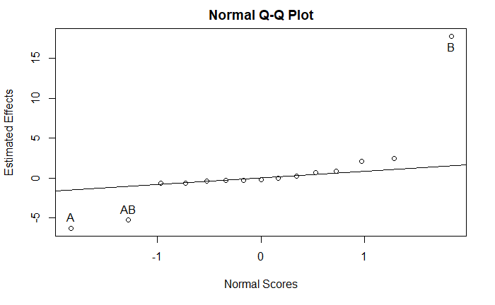

```r
daewr::fullnormal(coef(modf)[-1], alpha = 0.025)
```

ほとんどはライン上にのる。A, B, AxBがはずれていることから、この3つの効果は有意であるといえる（Estimate どおりやん？） ライン上の点は有意ではなく、このラインの傾きはestimate of the standard error of an effect

half-normal plot (normal plotを４５度で折りたたんだのと同じ)

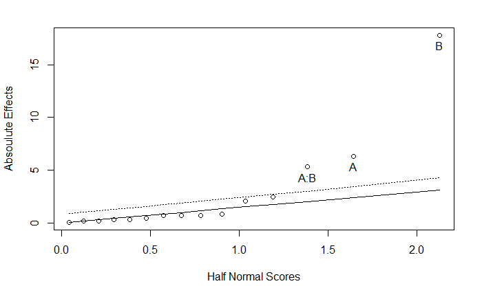

おなじこと。でもラインを引くのがより簡単。

interaction があるので主効果だけでは解釈がつかないので図interaction plot をみること